# Confounding

Rafael A. Irizarry  
May 4, 2016

### Correlation is not causation

One of the most important lessons you should take from this or any other data analysis course.

Most common reason: **confounders**

- Observe a correlation or association between \( X \) and \( Y \)
- Strictly the result of both \( X \) and \( Y \) depending on an extraneous variable \( Z \).

### Example: Gender and research funding success in the Netherlands

A recent [PNAS paper](http://www.pnas.org/content/112/40/12349.abstract) analyzed success rates from funding agencies and concluded that

> Our results reveal gender bias favoring male applicants over female applicants in the prioritization of their “quality of researcher” (but not “quality of proposal”) evaluations and success rates, as well as in the language use in instructional and evaluation materials.

### The Data

The main evidence for this conclusion comes down to a comparison of the percentages

```
      Awarded Not Awarded
Men       290        1345
Women     177        1011
```

Difference in percentage:

```
Men : 17.7 Women 14.9
```

```
p-value: 0.0509
```

So there is an association. But can we infer causation here?

### Response

[A response](http://www.pnas.org/content/112/51/E7036.extract) was published a few months later titled *No evidence that gender contributes to personal research funding success in The Netherlands: A reaction to van der Lee and Ellemers* which concluded

> However, the overall gender effect borders on statistical significance, despite the large sample. Moreover, their conclusion could be a prime example of Simpson’s paradox (2, 3); if a higher percentage of women apply for grants in more competitive scientific disciplines (i.e., with low application success rates for both men and women), then an analysis across all disciplines could incorrectly show “evidence” of gender inequality.

### Example of Simpson's Paradox

Admission data from U.C. Berkeley 1973 showed that more men were being admitted than women: 44% men were admitted compared to 30% women. This actually led to a [lawsuit](http://en.wikipedia.org/wiki/Simpson%27s_paradox#Berkeley_gender_bias_case). See: PJ Bickel, EA Hammel, and JW O'Connell. Science (1975). Here is the data:

Here is the data:

```
Proportion of men admitted: 0.445
```

```
Proportion of women admitted: 0.303
```

### Statistical Test

A chi-square test clearly rejects the hypothesis that gender and admission are independent:

```
      Admitted Not Admitted
Men       1198         1493
Women      557         1278
```

```
[1] 9.14e-22
```

### A Closer Look

| Major | Male | Female | difference |
| --- | --- | --- | --- |
| A | 62 | 82 | -20 |
| B | 63 | 68 | -5 |
| C | 37 | 34 | 3 |
| D | 33 | 35 | -2 |
| E | 28 | 24 | 4 |
| F | 6 | 7 | -1 |

What's going on?

### Confounder

- \( X \) is 1 for men and 0 for women,
- \( Y \) is 1 for those admitted to UC Berkeley and 0 otherwise

\( X \) and \( Y \) are correlated.

But let \( Z \) be major. \( Z \) is correlated with both \( X \) and \( Y \).

### Percent of Applicants That Are Female by Major

| major | percent_female |
| --- | --- |
| B | 4.27 |
| A | 11.58 |
| D | 47.35 |
| F | 47.76 |
| C | 64.60 |
| E | 67.30 |

Compare for major B and major E.

### Admission Rage by Major

But \( Z \) is also correlated with \( Y \). Some majors admit more students than others:

| major | percent_admitted |
| --- | --- |
| F | 6.48 |
| E | 25.31 |
| D | 33.95 |
| C | 35.06 |
| B | 63.21 |
| A | 64.31 |

Compare major F to major A.

### Confounding Visualized

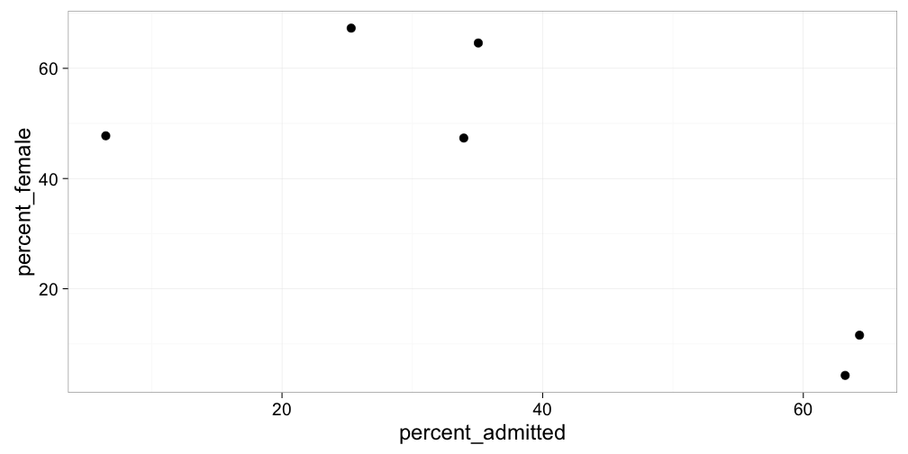

### Confounding explained graphically

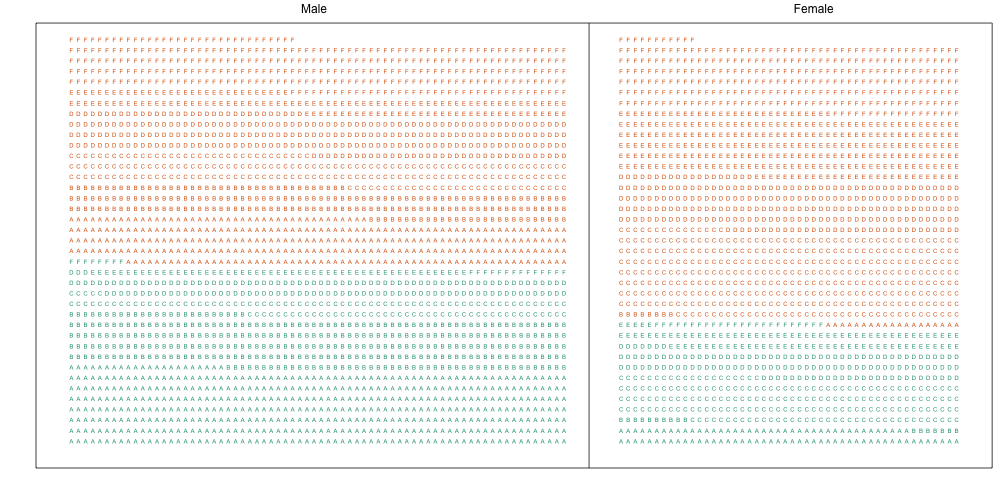

### Confounding explained graphically

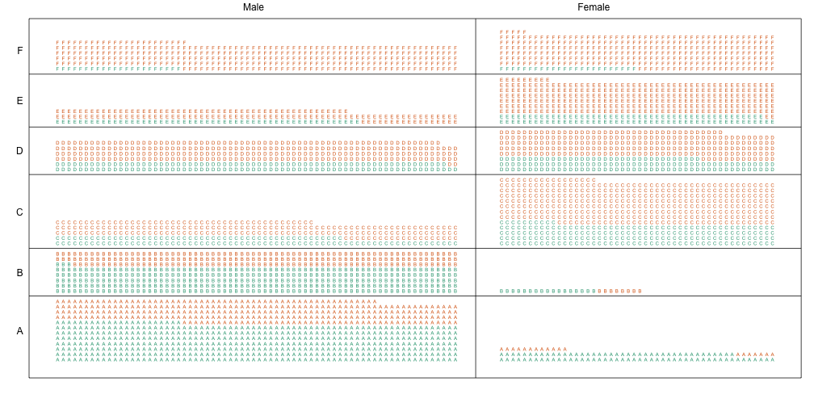

### Average after stratifying

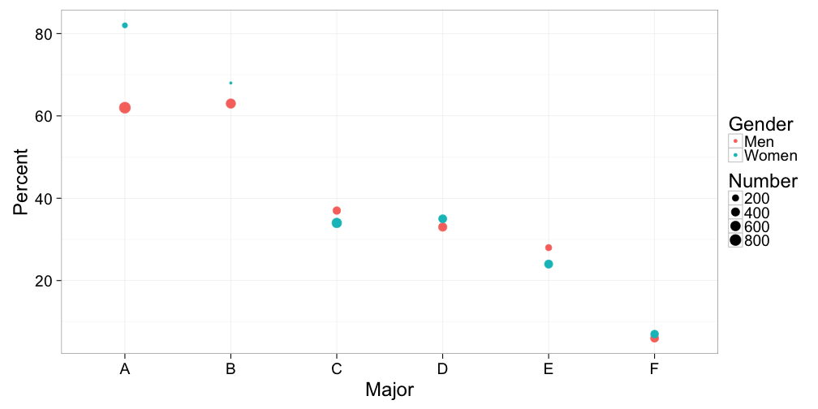

```
Average:  -3.5
```

### Back to the Netherlands

Unfortunately the data for the paper is included as a table in a [pdf document](http://www.pnas.org/content/suppl/2015/09/16/1510159112.DCSupplemental/pnas.201510159SI.pdf).

Fortunately, there is an R package that let's use read in text contained in pdf files.

### After some wrangling

|  | discipline | applications_total | applications_men | applications_women | awards_total | awards_men | awards_women | success_rates_total | success_rates_men | success_rates_women |
| --- | --- | --- | --- | --- | --- | --- | --- | --- | --- | --- |
| 2 | Chemical sciences | 122 | 83 | 39 | 32 | 22 | 10 | 26.2 | 26.5 | 25.6 |
| 3 | Physical sciences | 174 | 135 | 39 | 35 | 26 | 9 | 20.1 | 19.3 | 23.1 |
| 4 | Physics | 76 | 67 | 9 | 20 | 18 | 2 | 26.3 | 26.9 | 22.2 |
| 5 | Humanities | 396 | 230 | 166 | 65 | 33 | 32 | 16.4 | 14.3 | 19.3 |
| 6 | Technical sciences | 251 | 189 | 62 | 43 | 30 | 13 | 17.1 | 15.9 | 21.0 |
| 7 | Interdisciplinary | 183 | 105 | 78 | 29 | 12 | 17 | 15.8 | 11.4 | 21.8 |
| 8 | Earth/life sciences | 282 | 156 | 126 | 56 | 38 | 18 | 19.9 | 24.4 | 14.3 |
| 9 | Social sciences | 834 | 425 | 409 | 112 | 65 | 47 | 13.4 | 15.3 | 11.5 |
| 10 | Medical sciences | 505 | 245 | 260 | 75 | 46 | 29 | 14.9 | 18.8 | 11.2 |

### Stratify by Discipline

| discipline | difference | p.value |
| --- | --- | --- |
| Interdisciplinary | -10.4 | 0.090 |
| Technical sciences | -5.1 | 0.466 |
| Humanities | -5.0 | 0.242 |
| Physical sciences | -3.8 | 0.766 |
| Chemical sciences | 0.9 | 1.000 |
| Social sciences | 3.8 | 0.131 |
| Physics | 4.7 | 1.000 |
| Medical sciences | 7.6 | 0.022 |
| Earth/life sciences | 10.1 | 0.050 |

### Differences Normal QQ-plot

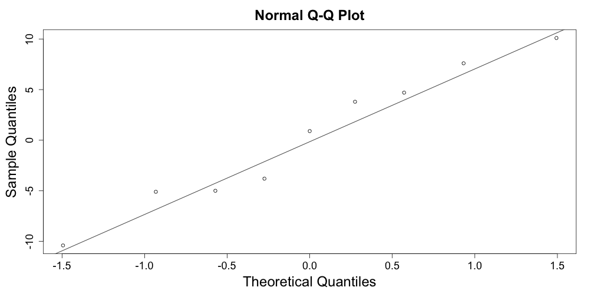

### Confounding As Before

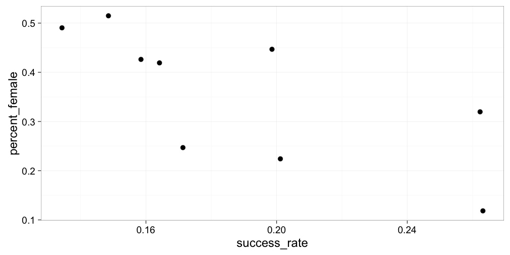

### Stratify by Discipline

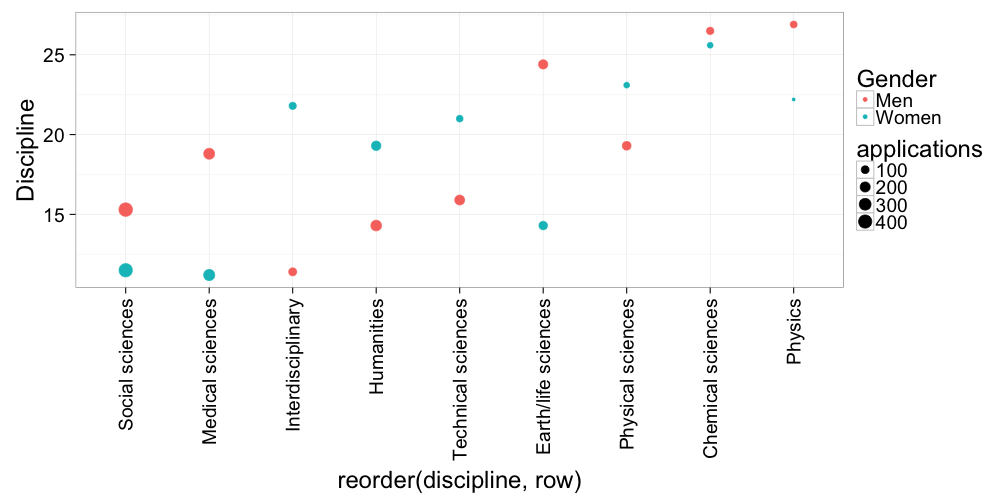

Here the average of the per discipline difference is

```
[1] 0.311
```

### Bonus: Simpson's Paradox in baseball

Simpson's Paradox is commonly seen in baseball statistics. Here is a well known example in which David Justice had a higher batting average than Derek Jeter in both 1995 and 1996, but Jeter had a higher overall average:

|  | 1995 | 1996 | Combined |
| --- | --- | --- | --- |
| Derek Jeter | 12/48 (.250) | 183/582 (.314) | 195/630 (.310) |
| David Justice | 104/411 (.253) | 45/140 (.321) | 149/551 (.270) |

The confounder here is games played. Jeter played more games during the year he batted better, while the opposite is true for Justice.